# Máster Universitario en Ciencia de Datos

# Tipología y ciclo de vida de los datos: PRA2

Autor: Pablo Benito y Miquel Rived

Junio 2021

```r
# Cargamos los paquetes R que vamos a usar
library(ggplot2)
library(dplyr)
library(knitr)
library(stringr)
library(lubridate)
library(purrr)
library(RcmdrMisc)
# library(ggbiplot)
library(summarytools)
library(kableExtra)
```

# 1 Descripción del dataset. ¿Por qué es importante y qué pregunta/problema pretende responder?

El dataset empleado en esta práctica es el obtenido en la PRA1 del semestre pasado y es el resultado de un proceso de *scraping* de la web de *reviews* de cámaras digitales dpreview.com. Contiene 2490 registros con 125 columnas de tipo numérico y categórico, representando cada fila una cámara digital.

Lo más interesante del conjunto de datos extraído es la gran cantidad de especificaciones diferentes que se encuentran, así como el gran abanico de cámaras digitales que lo abarcan, además de que al haber sido extraídas de una web, constituyen datos reales referentes a cámaras.

En primer lugar se quiere analizar que características técnicas afectan más en el aumento de precio de una cámara digital.

Por otro lado, se tratará de determinar qué cámaras son las más valoradas por los usuarios o los expertos, por lo que se pretenderá analizar las marcas más valoradas, si el precio influye en la valoración final, o que tipo de especificaciones son las que buscan los usuarios en una cámara digital para realizar una valoración alta.

Los datos permiten responder a preguntas del tipo:

- ¿Cuál es la cámara mejor valorada por los usuarios?
- ¿Cuál es la cámara más cara y más ergónomica?
- ¿Qué cámara es capaz de disparar más fotografías en modo ráfaga?
- ¿Cuál es la cámara con GPS más ligera y mayor autonomía de batería?

Estas preguntas pueden variar a lo largo de las prácticas, ya que disponemos de una gran variedad de cámaras y campos para analizarlas que seguro que al visualizar con mayor detenimiento nos hacen hacernos nuevas preguntas.

La diferencia principal con los otros estudios encontrados de dpreview.com es la gran variedad de campos que hemos seleccionado para analizar las cámaras.

# 2 Integración y selección de los datos de interés a analizar

> Se debe abrir el archivo de datos y examinar el tipo de datos con los que R ha interpretado cada variable. Examinar también los valores resumen de cada tipo de variable.

En primer lugar cargamos el archivo utilizando la función `read.csv`. añadimos el parámetro `stringsAsFactors=False` para que no convierta en factores los atributos que detecte como `String`. Posteriormente, nosotros realizaremos esa conversión para aquellos campos que consideremos oportuno.

```r
# Cargamos el fichero de datos
data <- read.csv('dpreview.csv',stringsAsFactors = FALSE)
```

Verificamos el tipo de datos asignado por R a cada atributo utilizando el comando `str` (`structure`):

```r
# Verificamos la estructura del conjunto de datos
str(data)
```

```
## 'data.frame':    2490 obs. of  125 variables:
##  $ Maximum.shutter.speed..electronic.: chr  "" "" "1/16000 sec" "1/32000 sec" ...
##  $ review_score                      : num  NA NA NA NA NA NA NA NA 87 NA ...
##  $ Build.quality                     : num  NA NA NA NA NA ...
##  $ Number.of.cross.type.focus.points : int  25 NA NA NA NA NA NA NA NA NA ...
##  $ Autofocus                         : chr  "Contrast Detect (sensor)Phase DetectMulti-areaCenterSelective single-pointTrackingSingleContinuousTouchFace DetectionLive View" "Contrast Detect (sensor)Phase DetectMulti-areaCenterSelective single-pointTrackingSingleContinuousTouchFace DetectionLive V…
##  $ link                              : chr  "https://www.dpreview.com/products/pentax/slrs/pentax_k3iii" "https://www.dpreview.com/products/sigma/slrs/sigma_fpl" "https://www.dpreview.com/products/fujifilm/slrs/fujifilm_gfx100s" "https://www.dpreview.com/products/fujifilm/slrs/fujifilm_xe4" ...
##  $ Format                            : chr  "MPEG-4, H.264" "MPEG-4, H.264" "MPEG-4, H.264, H.265" "MPEG-4, H.264" ...
##  $ Touch.screen                      : chr  "Yes" "Yes" "Yes" "Yes" ...
##  $ brand                             : chr  "Pentax" "Sigma" "Fujifilm" "Fujifilm" ...
##  $ Screen.dots                       : chr  "1,620,000" "2,100,000" "2,360,000" "1,620,000" ...
##  $ Continuous.drive                  : chr  "12.0 fps" "10.0 fps" "5.0 fps" "20.0 fps" ...
##  $ Microphone.port                   : chr  "Yes" "Yes" "Yes" "Yes" ...
##  $ Minimum.shutter.speed             : chr  "30 sec" "30 sec" "30 sec" "4 sec" ...
##  $ Shutter.priority                  : chr  "Yes" "Yes" "Yes" "Yes" ...
```

[output cut: 86 more lines]

Los atributos identificados, junto a su significado se resumen en la siguiente tabla:

```r
description_df <- data.frame (
                    #campo  = colnames(data),
                    tipo = sapply(data, class),
                    descripción = c(
                      "Velocidad de obturación máxima .",
                      "Puntuación de review",
                      "Puntuación calidad de construcción",
                      "Número de puntos de enfoque",
                      "Tipo de autofoco",
                      "Enlace a la página",
                      "Formatos de almacenamiento de vídeo",
                      "Pantalla táctil",
                      "Marca",
                      "Puntos de la pantalla",
                      "Disparos en modo ráfaga",
                      "Conexión para micrófono",
                      "Velocidad de obturación mínima",
                      "Prioridad de obturador",
                      "Dimensiones",
                      "Número de lentes",
                      "Puntuación de rendimiento",
                      "Enlace a la review",
                      "Amplificación del visor",
                      "Observaciones sobre la estabilización de imagen",
                      "Puntuación de calidad de pantalla",
                      "Observaciones sobre GPS",
                      "Número de usuarios que poseen la cámara",
                      "ISO mínimo",
                      "Puntuación de visor",
                      "Puntuación de velocidad y respuesta",
                      "Zoom óptico",
                      "Número de usuarios que desean tener la cámara",
                      "Modos de flash",
                      "Balances de blancos personalizados",
                      "Formato sin compresión",
                      "Fecha de publicación",
                      "Grabación de timelapse",
                      "Preajustes de balances de blancos",
                      "Multiplicador de la distancia focal",
                      "Resolución máxima",
                      "Puntuación de calidad de vídeo",
                      "Vista en directo",
                      "Descripción de la batería",
                      "Resolución del sensor",
                      "ISO máximo",
                      "Tipo de pantalla",
                      "Familia de la cámara",
                      "Puntuación de imagen fija",
                      "Cobertura del visor",
                      "Mando a distancia",
                      "Puntuación general",
                      "Tamaño del sensor",
                      "Velocidad de obturación máxima",
                      "Modos de medición",
                      "Estanqueidad",
                      "Observaciones sobre conexión inalámbrica",
                      "Distancia focal equivalente",
                      "Modelo de cámara",
                      "Formato de bateria",
                      "Resolución del visor",
                      "Puntuación de modo vídeo",
                      "Modo de pantalla articulada",
                      "Puntuación de calidad de imagen en RAW.",
                      "Puntuación de conectividad",
                      "Premio (Gold, Silver)",
                      "Niveles de calidad JPEG",
                      "Tamaño de la pantalla",
                      "Peso con batería", # Extraer gramos por expresión regular
                      "Píxeles efectivos",
                      "Especificaciones rápidas",
                      "Montura de lente",
                      "Modo de exposición manual",
                      "Puntuación de medición y enfoque",
                      "Tipo de sensor",
                      "Distancia mínima de enfoque",
                      "Durabilidad",
                      "Altavoz",
                      "Resoluciones",
                      "Número de usuarios que han poseido la cámara",
                      "Puntuación de calidad de imagen JPG",
                      "Puntuación de la óptica",
                      "Tipo de visor",
                      "Precio recomendado", # extraer mediante expresión regular el número
                      "Puntuación de ergonomía y manejo",
                      "Puntuación de rendimiento de flash",
                      "GPS",
                      "Puntuación de rendimiento en velocidad",
                      "Cuenta atrás",
                      "USB",
                      "Otras resoluciones",
                      "Puntuación de características",
                      "Wireless",
                      "Flash incluido",
                      "Compensación de la exposición",
                      "Puntuación de exactitud de exposición y enfoque",
                      "Puntuación de ergonomía y manejo",
                      "Flash externo",
                      "AE Bracketing",
                      "Ciclos de vida de la batería",
                      "Carga por USB",
                      "HDMI",
                      "Modos",
                      "Zoom digital",
                      "Apertura máxima",
                      "Rango del flash",
                      "ISO",
                      "Puntuación de review (porcentaje)",
                      "Modos de escena",
                      "Enfoque manual",
                      "Estabilización de imagen",
                      "Prioridad de apertura",
                      "Orientación del sensor" ,
                      "Puntuación CIPA de estabilización de imagen",
                      "Observaciones sobre grabación en vídeo",
                      "URL de imagen de la cámara",
                      "Tipo de micrófono",
                      "Puntuación con rendimeinto con luz baja e ISO alto",
                      "Campo de visión",
                      "Bracketing de balance de blancos",
                      "Puntuación de las características de la camera y fotografía",
                      "Procesador",
                      "Ratio de imagen ancho x alto",
                      "Distancia mínima modo macro",
                      "Tipo de cuerpo", # IMPORTANTE
                      "Conector de cascos",
                      "Número de reviews", # Extraer número con expresión regular
                      "Tipos de almacenamientos",
                      "Número de puntos de enfoque", # IMPORTANTE
                      "Almacenamiento incluido")
                  )
kable(description_df,caption="**Propiedades de las cámaras**") %>% kable_styling()
```

**Propiedades de las cámaras**

|  | tipo | descripción |
| --- | --- | --- |
| Maximum.shutter.speed..electronic. | character | Velocidad de obturación máxima . |
| review_score | numeric | Puntuación de review |
| Build.quality | numeric | Puntuación calidad de construcción |
| Number.of.cross.type.focus.points | integer | Número de puntos de enfoque |
| Autofocus | character | Tipo de autofoco |
| link | character | Enlace a la página |
| Format | character | Formatos de almacenamiento de vídeo |
| Touch.screen | character | Pantalla táctil |
| brand | character | Marca |
| Screen.dots | character | Puntos de la pantalla |
| Continuous.drive | character | Disparos en modo ráfaga |
| Microphone.port | character | Conexión para micrófono |
| Minimum.shutter.speed | character | Velocidad de obturación mínima |
| Shutter.priority | character | Prioridad de obturador |
| Dimensions | character | Dimensiones |
| Number.of.lenses | integer | Número de lentes |
| Performance | numeric | Puntuación de rendimiento |
| review_link | character | Enlace a la review |
| Viewfinder.magnification | character | Amplificación del visor |
| Image.stabilization.notes | character | Observaciones sobre la estabilización de imagen |
| Screen.Quality | numeric | Puntuación de calidad de pantalla |
| GPS.notes | character | Observaciones sobre GPS |
| own_gear | integer | Número de usuarios que poseen la cámara |
| Boosted.ISO..minimum. | integer | ISO mínimo |
| Viewfinder…screen.rating | numeric | Puntuación de visor |
| Speed.and.Responsiveness | numeric | Puntuación de velocidad y respuesta |
| Optical.zoom | character | Zoom óptico |
| want_gear | integer | Número de usuarios que desean tener la cámara |
| Flash.modes | character | Modos de flash |
| Custom.white.balance | character | Balances de blancos personalizados |

[output cut: 95 more lines]

En primer lugar, a continuación mostraremos las columnas que vamos a seleccionar del dataset, además de renombrarlas a los nombres indicados.

## 2.1 Variables cuantitativas

```r
data<- rename(data,
               puntuacion.calidad_construccion=Build.quality,
               puntuación.rendimiento=Performance,
               puntuacion.calidad.pantalla=Screen.Quality,
               puntuacion.visor=Viewfinder...screen.rating,
               puntuacion.velocidad_respuesta=Speed.and.Responsiveness,
               puntuacion.calidad_video=Video.Quality,
               puntuacion.calidad_imagen_fija=Still.Image.Quality,
               puntuacion.general=Value,
               puntuacion.modo_video=Movie...video.mode,
               puntuacion.puntuacion_calidad_raw=Image.quality..raw.,
               puntuacion.conectividad=Connectivity,
               puntuacion.precision=Metering...focus.accuracy,
               puntuacion.calidad_jpg=Image.quality..jpeg.,
               puntuacion.optica=Optics,
               puntuacion.ergonomia_manejo=Ergonomics...handling,
               puntuacion.rendimento_flash=Flash.performance,
               puntuacion.rendimiento_velocidad=Performance..speed.,
               puntuacion.caracteristicas=Features,
               puntuacion.precision_exposicion_enfoque=Exposure.and.focus.accuracy,
               puntuacion.pro_review=review_value,
               puntuacion.luz_baja_alto_ISO=Low.light...high.ISO.performance,
               puntuacion.caracteristicas_camara_foto=Camera.and.Photo.Features)
```

- Las relativos a las **características físicas de la cámara**:
  - `Weight..inc..batteries`: Peso. Renombramos a `caracteristicas.peso`
  - `Dimensions`: Dimensiones (ancho x alto x fondo). Renombramos a `caracteristicas.dimensiones`

```r
data<- rename(data,
               caracteristicas.peso=Weight..inc..batteries.,
               caracteristicas.dimensiones=Dimensions)
```

- Las relativas al **interés por parte de los usuarios de la comunidad** de dpreview:
  - own_gear. Renombramos a `usuario.tiene`
  - had_gear. Renombramos a `usuario.ha_tenido`
  - want_gear. Renombramos a `usuario.desea`
  - review_score: Puntuación media por parte de los usuarios de la comunidad. Renombramos a `usuario.puntuacion`

```r
data<- rename(data,
               usuario.tiene=own_gear,
               usuario.ha_tenido=had_gear,
               usuario.desea=want_gear,
               usuario.puntuacion=review_score)
```

- El **precio de la cámara**: `MSRP`. Renombramos a `precio`

```r
data<- rename(data,
               precio=MSRP)
```

- Las relativas a **características técnicas** de la cámara:
  - `Max.resolution`: resolución, renombramos a `caracteristicas.resolucion` -`Maximum.shutter.speed`: velocidad máxima de obturador, renombramos a `caracteristicas.velocidad_obturador`

```r
data<- rename(data,
               caracteristicas.resolucion=Max.resolution,
               caracteristicas.velocidad_obturador=Maximum.shutter.speed
              )
```

## 2.2 Variables cualitativas

- Marca y modelo de la cámara:
  - `Brand`: Marca, renombramos a `marca`
  - `name`: Modelo, renombramos a `modelo`
- Otras características:
  - `Body.type`: Tipo de cuerpo, renombramos a `tipo_cuerpo`
  - `Sensor.type`: Tipo de sensor, renombramos a `tipo_sensor`
  - `announcement_date`: Fecha de lanzamiento, renombramos a `fecha_lanzamiento`

```r
data<- rename(data,
               marca=brand,
               modelo=name,
               tipo_cuerpo=Body.type,
               tipo_sensor=Sensor.type,
               fecha_lanzamiento=announcement_date
              )
```

Convertimos a factor los atributos:

```r
data$marca<-as.factor(data$marca)
data$tipo_cuerpo<-as.factor(data$tipo_cuerpo)
data$tipo_sensor<-as.factor(data$tipo_sensor)
data$caracteristicas.velocidad_obturador<-as.factor(data$caracteristicas.velocidad_obturador)
data$GPS <- as.factor(data$GPS)
```

Finalmente aplicamos la reducción de la dimensionalidad, filtrando únicamente las columnas que nos interesan

```r
data <- data[ , grepl( "puntuacion|caracteristicas|tipo_|fecha_lanzamiento|marca|modelo|precio|GPS" , names( data ) ) ]
```

## 2.3 Extraccción de valores numéricos

### 2.3.1 Atributo `precio`

Los valores de la columna `precio` tiene diversos tipos de valores. En la mayoría de las filas contiene un único precio en dólares, precedido del símbolo de dolar (p.ej. `$899`), pero en algunos casos incluye varios precios en función del kit a comprar (con objetivo, sin objetivo, con varios ojetivos,…) y en otros casos se muestra el precio tanto en dólares como en otras monedas (euro y libras).

Para simplificar la extracción, nos quedaremos con el primer precio que aparezca precedido del símbolo del dólar utilizando una expresión regular.

Otras posibles alternativas en el tratamiento de este atributo podría haber sido obtener todos los posibles valores precedidos del símbolo dólar y quedarnos con el máximo, o hacer una conversión entre divisas según el cambio euro->dólar y libra->dolar.

```r
data$precio<-as.integer(str_extract(str_extract(data$precio, "(\\$\\d+)"),"(\\d+)"))
```

### 2.3.2 Atributo `puntuacion.pro_review`

Este atributo contiene un porcentaje que incluye el símbolo `%`. Interesa convertirlo a entero y eliminar ese porcentaje. Utilizaremos para ello una expresión regular y la función `str_extract` del paquete `stringr`

```r
data$puntuacion.pro_review<-as.integer(str_extract(data$puntuacion.pro_review, "(\\d+)"))
```

### 2.3.3 Atributo `caracteristicas.peso`

Este atributo expresa el peso tanto en gramos como en libras y onzas. Utilizaremos una expresión regular para quedarnos con el peso en gramos

```r
data$caracteristicas.peso<-as.integer(str_extract(data$caracteristicas.peso, "(\\d+)"))
```

### 2.3.4 Atributo `caracteristicas.dimensiones`

Este atributo expresa el tamaño (ancho x alto x fondo) en milímetros. A partir del mismo es posible establecer una nueva variable volumen

```r
data$dim.ancho<-as.integer(str_match(data$caracteristicas.dimensiones, "(\\d+) x (\\d+) x (\\d+)")[,2])
data$dim.alto<-as.integer(str_match(data$caracteristicas.dimensiones, "(\\d+) x (\\d+) x (\\d+)")[,3])
data$dim.fondo<-as.integer(str_match(data$caracteristicas.dimensiones, "(\\d+) x (\\d+) x (\\d+)")[,4])

# Calculamos el volumen
data$caracteristicas.volumen <- data$dim.ancho  * data$dim.alto * data$dim.fondo

# data %>% select(caracteristicas.dimensiones,dim.ancho,dim.alto,dim.fondo, caracteristicas.volumen)

# Eliminamos las columnas innecesarias
data <- data %>% select (-c(caracteristicas.dimensiones,dim.ancho, dim.alto,dim.fondo))
```

## 2.4 Ajuste de variables discretas

### 2.4.1 Tipo de sensor

La variable `tipo_sensor` contiene diversos valores que se pueden agrupar en dos grandes grupos: CCD y CMOS. Realizamos esta simplificación:

```r
# https://stackoverflow.com/questions/25372082/create-column-based-on-presence-of-string-pattern-and-ifelse
data$tipo_sensor<-ifelse(grepl("CMOS",data$tipo_sensor),'CMOS','CCD')
```

## 2.5 Extracción de fecha

La fecha de lanzamiento de la cámara viene especificada en el atributo `fecha_lanzamiento`.

El formato del campo varía en función de si el lanzamiento ha sido hace menos de un año (p.ej. “`Announced 7 months ago`”), o hace más de un año (p.ej. “`Announced Jan 15, 2016`”). En cualquier caso, de cara al análisis sólo nos interesa quedarnos con el año de lanzamiento. Utilizaremos una expresión regular para obtener el año, y en caso de que no tenga éxito, asignaremos el valor actual.

```r
data$fecha_lanzamiento <- as.integer(str_extract(data$fecha_lanzamiento, "(\\d\\d\\d\\d)"))
# Asignamos por defecto al año 2020
data[is.na(data$fecha_lanzamiento),"fecha_lanzamiento"] = 2020
data$fecha_lanzamiento <-as.factor(data$fecha_lanzamiento)
```

## 2.6 Resumen de los datos

La fecha de lanzamiento de la cámara viene especificada en el atributo `fecha_lanzamiento`.

El formato del campo varía en función de si el lanzamiento ha sido hace menos de un año (p.ej. “`Announced 7 months ago`”), o hace más de un año (p.ej. “`Announced Jan 15, 2016`”). En cualquier caso, de cara al análisis sólo nos interesa quedarnos con el año de lanzamiento. Utilizaremos una expresión regular para obtener el año, y en caso de que no tenga éxito, asignaremos el valor actual.

```r
summary(data)
```

```
##  usuario.puntuacion puntuacion.calidad_construccion       marca
##  Min.   : 10.00     Min.   :28.57                   Canon    :303
##  1st Qu.: 77.47     1st Qu.:64.29                   Sony     :299
##  Median : 84.24     Median :75.71                   Nikon    :264
##  Mean   : 81.69     Mean   :74.25                   Fujifilm :253
##  3rd Qu.: 89.16     3rd Qu.:82.86                   Olympus  :253
##  Max.   :100.00     Max.   :98.57                   Panasonic:211
##  NA's   :446        NA's   :2131                    (Other)  :907
##  puntuacion.calidad.pantalla  GPS.notes         puntuacion.visor
##  Min.   :84.29               Length:2490        Min.   :21.43
##  1st Qu.:84.29               Class :character   1st Qu.:68.57
##  Median :84.29               Mode  :character   Median :78.57
##  Mean   :84.29                                  Mean   :75.51
##  3rd Qu.:84.29                                  3rd Qu.:85.71
##  Max.   :84.29                                  Max.   :97.14
##  NA's   :2487                                   NA's   :2220
##  puntuacion.velocidad_respuesta fecha_lanzamiento caracteristicas.resolucion
##  Min.   :71.43                  2007   : 178      Length:2490
##  1st Qu.:71.43                  2008   : 172      Class :character
##  Median :71.43                  2010   : 171      Mode  :character
##  Mean   :71.43                  2009   : 170
##  3rd Qu.:71.43                  2012   : 165
##  Max.   :71.43                  2011   : 162
##  NA's   :2487                   (Other):1472
##  puntuacion.calidad_video puntuacion.calidad_imagen_fija puntuacion.general
##  Min.   :78.57            Min.   :47.14                  Min.   :14.29
##  1st Qu.:78.57            1st Qu.:47.14                  1st Qu.:57.14
##  Median :78.57            Median :47.14                  Median :64.29
##  Mean   :78.57            Mean   :47.14                  Mean   :62.88
##  3rd Qu.:78.57            3rd Qu.:47.14                  3rd Qu.:71.43
##  Max.   :78.57            Max.   :47.14                  Max.   :95.71
##  NA's   :2487             NA's   :2487                   NA's   :2131
##  caracteristicas.velocidad_obturador    modelo          puntuacion.modo_video
##  1/2000 sec:892                      Length:2490        Min.   : 14.29
##  1/4000 sec:402                      Class :character   1st Qu.: 50.00
##  1/1000 sec:254                      Mode  :character   Median : 64.29
##            :190                                         Mean   : 63.78
##  1/8000 sec:146                                         3rd Qu.: 78.57
##  1/1500 sec:130                                         Max.   :100.00
##  (Other)   :476                                         NA's   :2145
```

[output cut: 49 more lines]

```
##  Min.   :87.14                          Compact                     :1336
##  1st Qu.:87.14                          Ultracompact                : 499
##  Median :87.14                          Rangefinder-style mirrorless: 138
##  Mean   :87.14                          SLR-like (bridge)           : 116
##  3rd Qu.:87.14                          Mid-size SLR                :  99
##  Max.   :87.14                          SLR-style mirrorless        :  90
##  NA's   :2487                           (Other)                     : 212
##  caracteristicas.volumen
##  Min.   :  48336
##  1st Qu.: 134059
##  Median : 222222
##  Mean   : 434752
##  3rd Qu.: 558260
##  Max.   :4831200
##  NA's   :54
```

# 3 Limpieza de datos

## 3.1 ¿Los datos contienen ceros o elementos vacíos? ¿Como gestionarías cada uno de estos casos?

### 3.1.1 Comprobar atributos con valores vacíos

Vamos a verificar si el dataset incluye elementos vacíos:

```r
sapply(data, function(x) sum(is.na(x)))
```

```
##                      usuario.puntuacion         puntuacion.calidad_construccion
##                                     446                                    2131
##                                   marca             puntuacion.calidad.pantalla
##                                       0                                    2487
##                               GPS.notes                        puntuacion.visor
##                                       0                                    2220
##          puntuacion.velocidad_respuesta                       fecha_lanzamiento
##                                    2487                                       0
##              caracteristicas.resolucion                puntuacion.calidad_video
##                                       0                                    2487
##          puntuacion.calidad_imagen_fija                      puntuacion.general
##                                    2487                                    2131
##     caracteristicas.velocidad_obturador                                  modelo
##                                       0                                       0
##                   puntuacion.modo_video       puntuacion.puntuacion_calidad_raw
##                                    2145                                    2190
##                 puntuacion.conectividad                    caracteristicas.peso
##                                    2308                                      95
##                    puntuacion.precision                             tipo_sensor
##                                    2220                                       0
##                  puntuacion.calidad_jpg                       puntuacion.optica
##                                    2131                                    2357
##                                  precio             puntuacion.rendimento_flash
##                                    2009                                    2402
##                                     GPS        puntuacion.rendimiento_velocidad
##                                       0                                    2401
##              puntuacion.caracteristicas puntuacion.precision_exposicion_enfoque
##                                    2131                                    2401
##             puntuacion.ergonomia_manejo                   puntuacion.pro_review
##                                    2131                                    2127
##            puntuacion.luz_baja_alto_ISO  puntuacion.caracteristicas_camara_foto
##                                    2131                                    2487
##                             tipo_cuerpo                 caracteristicas.volumen
##                                       0                                      54
```

Se comprueba que efectivamente el `dataset` contiene un gran número de elementos vacíos, especialmente en las columnas de puntuación. El primer tratamiento que realizaremos es asignar `NA` a los atributos con valor cadena vacía.

```r
data <- data %>% mutate_all(list(~na_if(.,"")))
```

Eliminamos todos aquellos atributos tipo “puntuación” que tengan más del 90% de atributos con valor `NA`

```r
#https://stackoverflow.com/questions/31848156/delete-columns-rows-with-more-than-x-missing
data.puntuacion <- data%>%select(starts_with("puntuacion"))
atributes_to_remove<-colnames(data.puntuacion[, which(colMeans(is.na(data.puntuacion)) > 0.9)])
data<-data %>% select(-atributes_to_remove)
```

Además, dado que nuestra variable objetivo es el precio, eliminamos todas aquellas filas para las que el precio no se encuentra definido. Esto supondrá una reducción significativa en el `dataset`.

```r
data <- data %>% filter (!is.na(precio))
```

### 3.1.2 Verificar duplicación de registros

No existe un campo ID. Se puede verificar la existencia de duplicados mediante la combinación de campos Brand+Name.

Para comprobar si hay algún registro repetido utilizamos la función `unique` que proporciona los elementos únicos de una lista, en combinación con la función `nrow`, que obtiene el número de filas de un dataframe.

```r
if (nrow(unique(data[,c("marca","modelo")]))!=nrow(data[,c("marca","modelo")])){
  print("Hay alguna cámara repetida")
}else{
  print("No hay ninguna cámara repetida")
}
```

```
## [1] "No hay ninguna cámara repetida"
```

### 3.1.3 Imputación de valores vacios

#### 3.1.3.1 Puntuaciones

Para todos los atributos de tipo ´puntuacion.xxxx´, imputamos inicialmente con la **media de la misma marca y tipo de cuerpo**:

```r
data<-data %>%
    group_by(marca,tipo_cuerpo) %>%
    mutate_each(funs(replace(., which(is.na(.)), mean(., na.rm=TRUE))),
       starts_with('puntuacion'))
```

En caso de los valores que sigan siendo `NA` utilizamos la **media de la marca**:

```r
data<-data %>%
    group_by(marca) %>%
    mutate_each(funs(replace(., which(is.na(.)), mean(., na.rm=TRUE))),
       starts_with('puntuacion'))
```

Y si continua siendo `NA` imputamos por la **media general de la puntuación**:

```r
data<-data %>%
    mutate_each(funs(replace(., which(is.nan(.)), mean(., na.rm=TRUE))),
       starts_with('puntuacion'))
```

## 3.2 Identificación y tratamiento de valores extremos

Identificamos a continuación los valores extremos. Nosotros lo realizaremos para los valores de precio, peso y la puntuación de proreview.

### 3.2.1 Precio

Veamos los valores extremos del precio de las cámaras

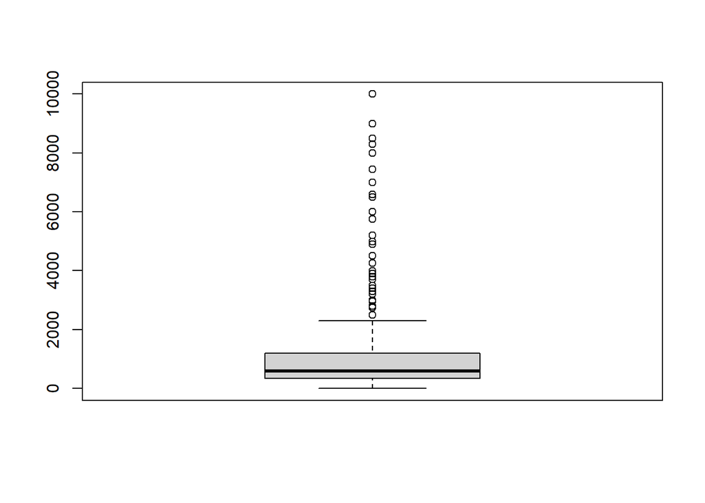

```r
boxplot(data$precio)
```

```r
out = boxplot.stats(data$precio)$out
out
```

```
##  [1] 2499 5999 6500 4895 5995 2999 3499 8295 3899 2499 8295 6499 5999 4500 6499
## [16] 3500 3999 5750 3999 9999 4995 2499 3699 2999 4995 2499 7995 4499 3399 7995
## [31] 2499 2795 3199 3299 4500 6595 6499 3199 3499 8995 5999 2950 6499 5195 7450
## [46] 3299 3000 3199 4250 7450 2499 3799 3699 3899 6995 3299 8499 2499 6499 2749
## [61] 3499 2999 5999
```

Para el precio tenemos muchos valores extremos. Como podemos comprobar los datos con la misma página de dpreview.com para ver si se ha realizado bien la extracción, antes de tomar cualquier decisión podemos comprobar si los datos se han extraído bien de la página.

Tras una breve comprobación, vemos como cámaras como LEICA M10-R vale 8295 dólares, LEICA M10 Monochrom vale también 8295 dólares, o Fujifilm GFX 100 Specs cuesta 9999 dólares.

Por lo tanto, tras comprobar los valores extremos en la web, vemos que no son errores sino valores reales. Y decidimos quedárnoslos y trabajar con ellos.

### 3.2.2 Peso

Veamos los valores extremos del peso de las cámaras

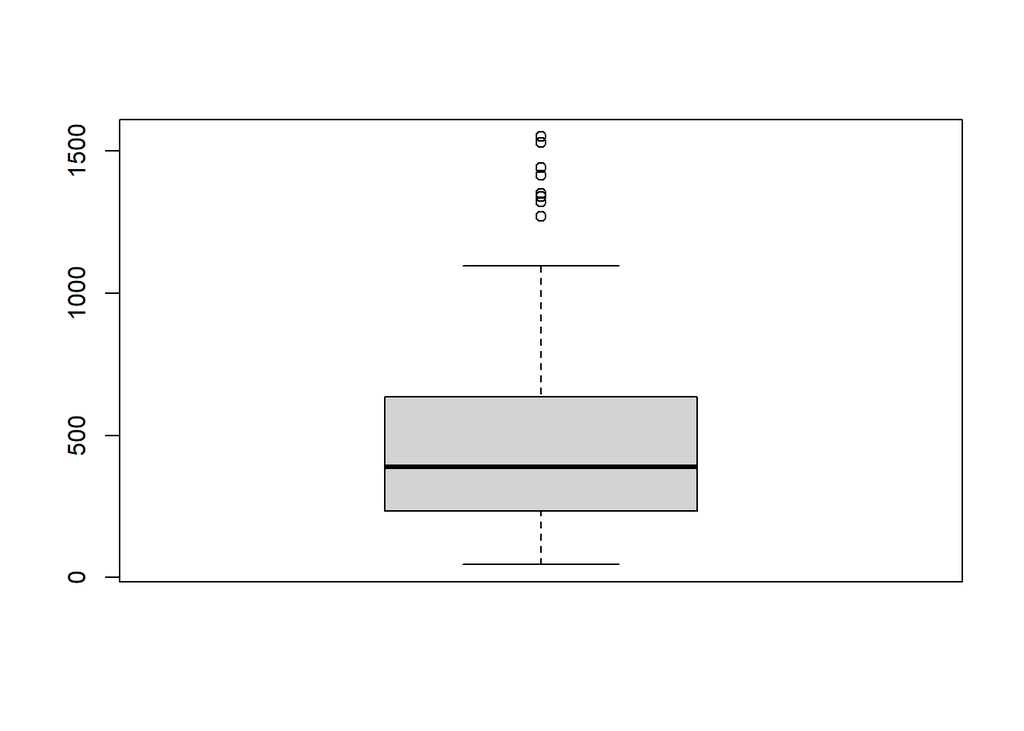

```r
boxplot(data$caracteristicas.peso)
```

```r
out = boxplot.stats(data$caracteristicas.peso)$out
out
```

```
## [1] 1440 1270 1320 1415 1530 1415 1550 1350 1340
```

```r
filter(data, caracteristicas.peso > 1700)$modelo
```

```
## character(0)
```

Por lo tanto, nos encontramos ante valores reales y trabajaremos con ellos.

### 3.2.3 Puntuacion.proreview

Veamos los valores extremos de la puntuación proreview de las cámaras

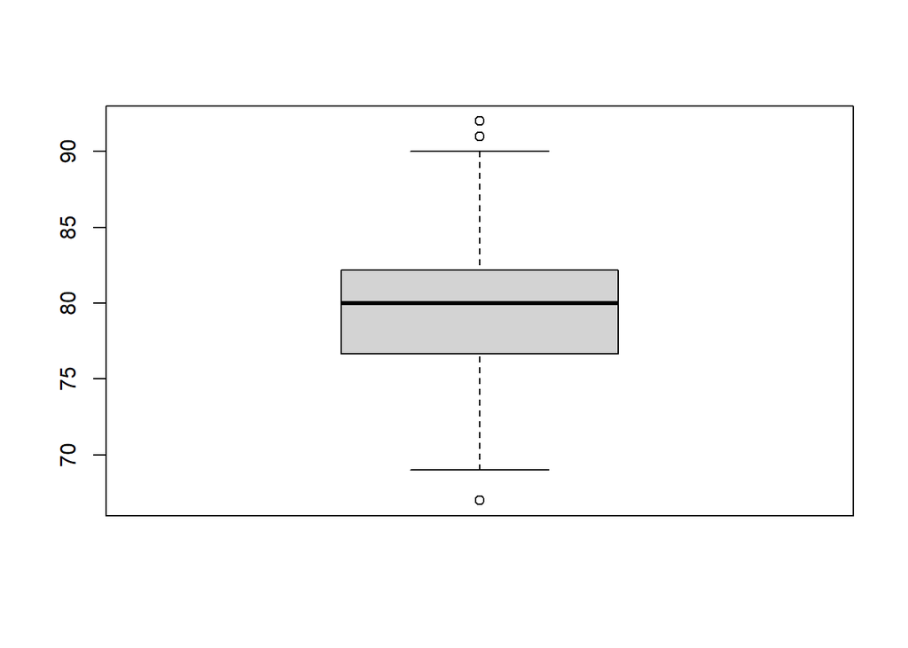

```r
boxplot(data$puntuacion.pro_review)
```

```r
out = boxplot.stats(data$puntuacion.pro_review)$out
out
```

```
## [1] 91 91 92 91 91 67
```

En este caso también nos encontramos varios valores extremos, pero todos se comprenden entre el 0 y el 100, por lo que los damos como buenos ya que son los valores entre los que puede estar la cámara.

## 3.3 Archivo limpio

Para guardar el `dataframe` resultado del procesamiento utilizamos la función `write.csv`:

```r
write.csv(data, 'dpreview_clean.csv', row.names = FALSE)
```

# 4 Análisis de los datos

## 4.1 Selección de los grupos de datos que se quieren analizar/comparar (planificación de los análisis a aplicar).

En primer lugar se seleccionan los datos que se quieren analizar/comparar. En este ejercicio, el objetivo es realizar los análisis exploratorios que se han determinado en el primer apartado.

Para ello se realizará la comprobación de normalidad y homogeneidad de la varianza.

Análisis estadístico para comparar los grupos de datos: - Análisis del precio en función del tipo de cuerpo - Análisis del tipo de sensor por fecha de lanzamiento - Análisis de la evolución del tipo de cuerpo. - Comparación de valoración de los usuarios entre cámaras Canon y Nicon - Creación de modelo para predecir la puntuación general de una cámara - Creación de modelo para predecir el precio de una cámara

## 4.2 Comprobación de la normalidad y la homogeneidad de la varianza

La comprobación de la normalidad es necesaria para poder realizar análisis posteriores como por ejemplo el contraste de hipótesis. Para la comprobación de la normalidad nos basaremos en el teorema del límite central, según el cual una muestra mayor de 30 se podrá considerar que sigue una distribución normal.

### 4.2.1 Precio en función del tipo de cuerpo

```r
cuerpos = na.omit(unique(data$tipo_cuerpo))
for (cuerpo in cuerpos){
  print(cuerpo)
  print(length(filter(data, tipo_cuerpo == cuerpo)$precio))

}
```

```
## [1] "Mid-size SLR"
## [1] 39
## [1] "Rangefinder-style mirrorless"
## [1] 78
## [1] "SLR-style mirrorless"
## [1] 73
## [1] "Large sensor compact"
## [1] 34
## [1] "Compact"
## [1] 123
## [1] "VR/Action camera"
## [1] 16
## [1] "Compact SLR"
## [1] 24
## [1] "SLR-like (bridge)"
## [1] 49
## [1] "Large SLR"
## [1] 8
## [1] "Ultracompact"
## [1] 37
```

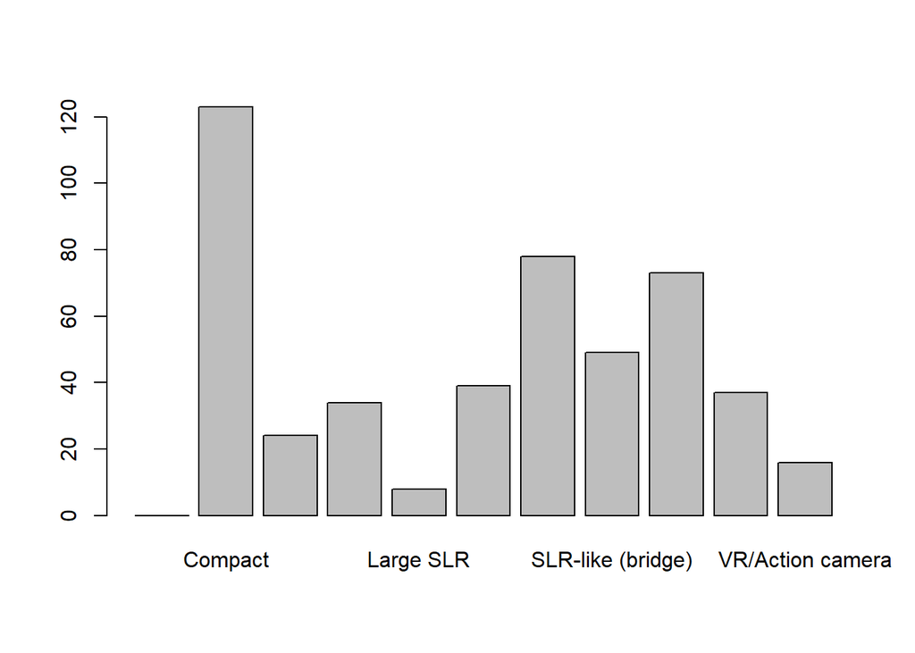

```r
plot(x = data$tipo_cuerpo)
```

## 4.3 Puntuación general para Nikon y Canon

```r
length( filter(data, marca=="Nikon")$puntuacion.general)
```

```
## [1] 75
```

```r
length( filter(data, marca=="Canon")$puntuacion.general)
```

```
## [1] 89
```

En este caso, ambos conjuntos superan las 30 muestras y podemos asumir normalidad por el TLC.

Procedemos a comprobar la homogeneidad de la varianza para los dos grupos mediante el test de Barlett.

```r
bartlett.test(list(data$puntuacion.general[data$marca == "Nikon"],data$puntuacion.general[data$marca == "Canon"]))
```

```
##
##  Bartlett test of homogeneity of variances
##
## data:  list(data$puntuacion.general[data$marca == "Nikon"], data$puntuacion.general[data$marca == "Canon"])
## Bartlett's K-squared = 26.87, df = 1, p-value = 2.176e-07
```

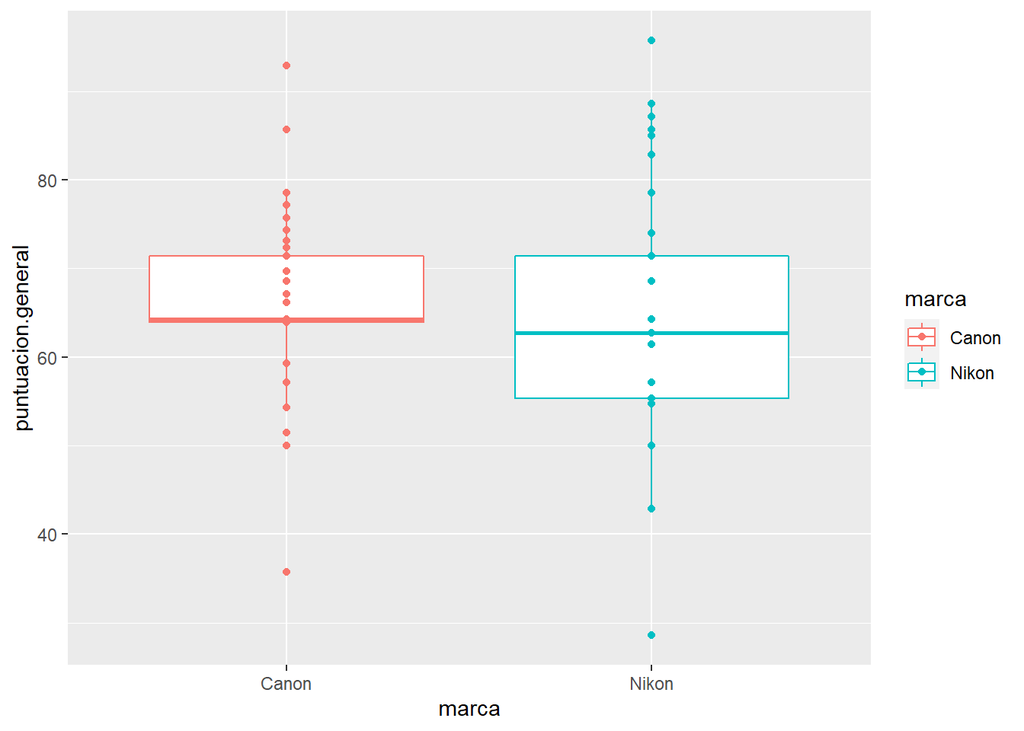

```r
data_canon_nikon = filter(data, marca %in% c("Nikon","Canon"))
ggplot(data=data_canon_nikon, aes(x=marca, y= puntuacion.general, colour = marca)) + geom_boxplot() + geom_point()
```

## 4.4 Aplicación de pruebas estadís<ticas para comparar los grupos de datos. En función de los datos y el objetivo del estudio, aplicar pruebas de contraste de hipótesis, correlaciones, regresiones, etc. Aplicar al menos tres métodos de análisis diferentes.

### 4.4.1 Correlación entre variables

En primer lugar vamos a realizar un análisis visual de la correlación entre las variables numéricas.

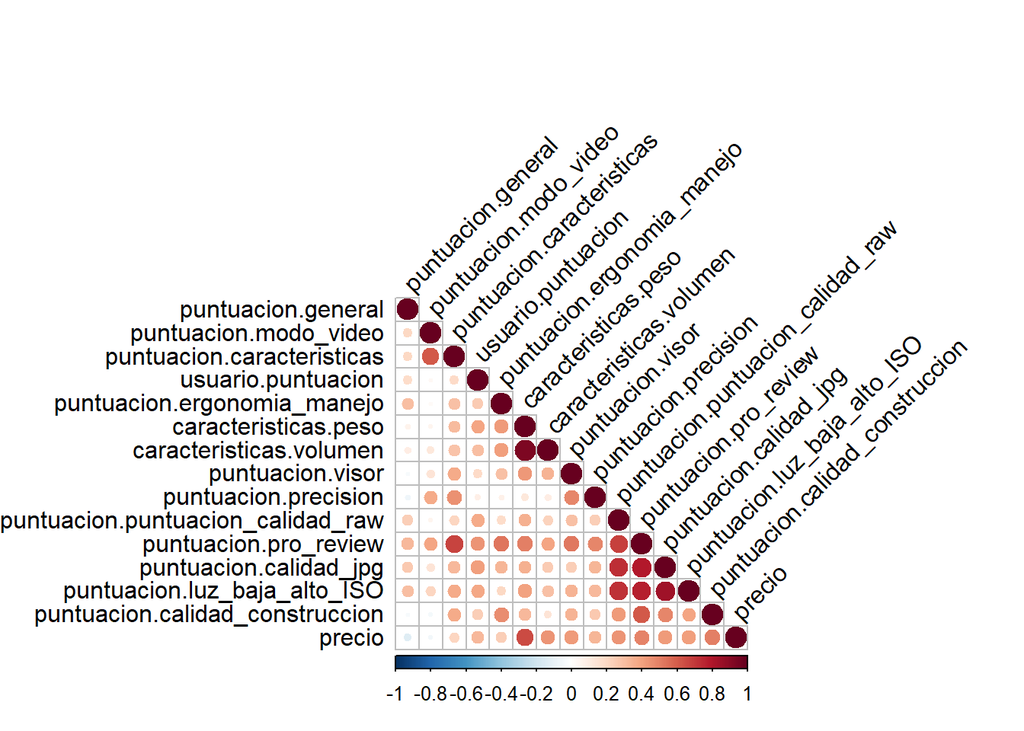

```
## $r
##                                   puntuacion.general puntuacion.modo_video
## puntuacion.general                                 1
## puntuacion.modo_video                            0.2                     1
## puntuacion.caracteristicas                       0.2                  0.61
## usuario.puntuacion                              0.18                 0.033
## puntuacion.ergonomia_manejo                      0.3                 0.027
## caracteristicas.peso                           0.066                 0.052
## caracteristicas.volumen                        0.097                  0.13
## puntuacion.visor                              -0.032                  0.15
## puntuacion.precision                           -0.07                  0.37
## puntuacion.puntuacion_calidad_raw               0.24                  0.05
## puntuacion.pro_review                           0.32                  0.39
## puntuacion.calidad_jpg                          0.26                  0.15
## puntuacion.luz_baja_alto_ISO                     0.3                  0.21
## puntuacion.calidad_construccion               -0.034                -0.049
## precio                                         -0.14                -0.053
##                                   puntuacion.caracteristicas usuario.puntuacion
## puntuacion.general
## puntuacion.modo_video
## puntuacion.caracteristicas                                 1
## usuario.puntuacion                                      0.19                  1
## puntuacion.ergonomia_manejo                             0.29               0.25
## caracteristicas.peso                                    0.31               0.39
## caracteristicas.volumen                                 0.28                0.3
## puntuacion.visor                                        0.37               0.19
## puntuacion.precision                                    0.45              0.085
## puntuacion.puntuacion_calidad_raw                       0.21               0.37
## puntuacion.pro_review                                   0.67               0.44
## puntuacion.calidad_jpg                                  0.32               0.41
## puntuacion.luz_baja_alto_ISO                            0.37               0.38
## puntuacion.calidad_construccion                         0.37               0.24
## precio                                                  0.21               0.32
##                                   puntuacion.ergonomia_manejo
## puntuacion.general
## puntuacion.modo_video
## puntuacion.caracteristicas
## usuario.puntuacion
## puntuacion.ergonomia_manejo                                 1
## caracteristicas.peso                                     0.42
```

[output cut: 384 more lines]

```
## puntuacion.caracteristicas
## usuario.puntuacion
## puntuacion.ergonomia_manejo
## caracteristicas.peso
## caracteristicas.volumen
## puntuacion.visor
## puntuacion.precision
## puntuacion.puntuacion_calidad_raw
## puntuacion.pro_review
## puntuacion.calidad_jpg
## puntuacion.luz_baja_alto_ISO
## puntuacion.calidad_construccion   1
## precio                            .                               1
## attr(,"legend")
## [1] 0 ' ' 0.3 '.' 0.6 ',' 0.8 '+' 0.9 '*' 0.95 'B' 1
```

```r
# Fuente: http://www.sthda.com/english/wiki/correlation-matrix-an-r-function-to-do-all-you-need
#install.packages("corrplot")
library(corrplot)
source("http://www.sthda.com/upload/rquery_cormat.r")
nums <- unlist(lapply(data, is.numeric))
rquery.cormat(data[ , nums])
```

```r
#corrplot(cor(data[, nums]), type="upper")
```

### 4.4.2 Análisis exploratorio

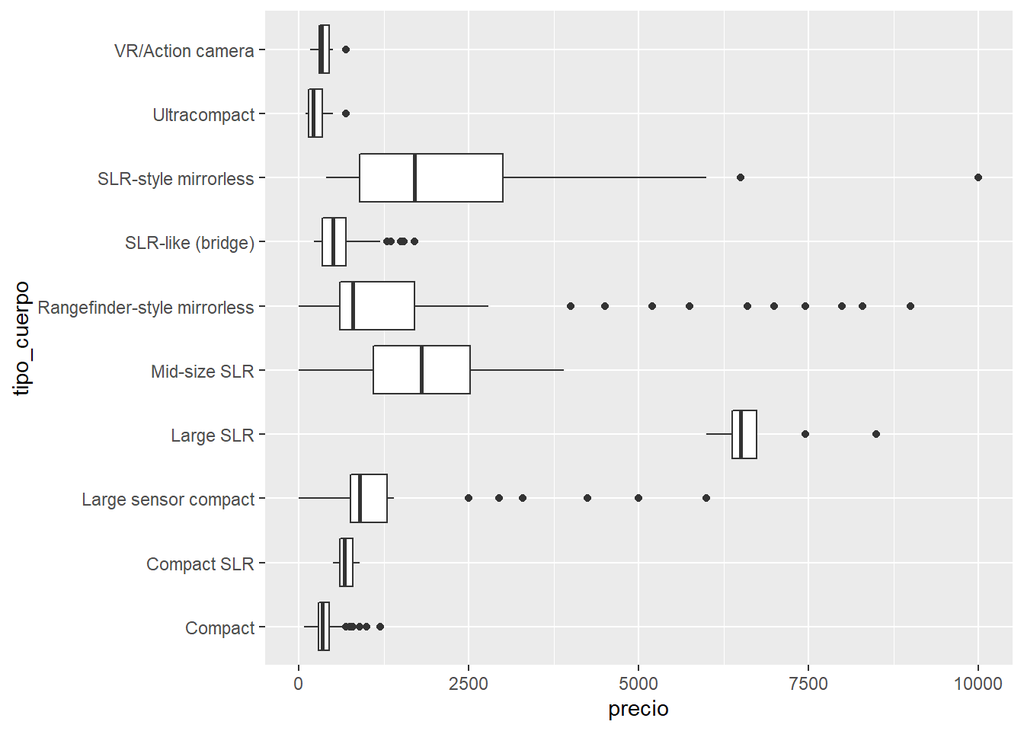

```r
ggplot(data, aes(x=precio, y=tipo_cuerpo)) +
    geom_boxplot()
```

Lógicamente las cámaras más caras son las SLR “grandes”, que son las que se emplean profesionalmente. Las compactas, ultracompactas y cámaras de acción son las más asequibles.

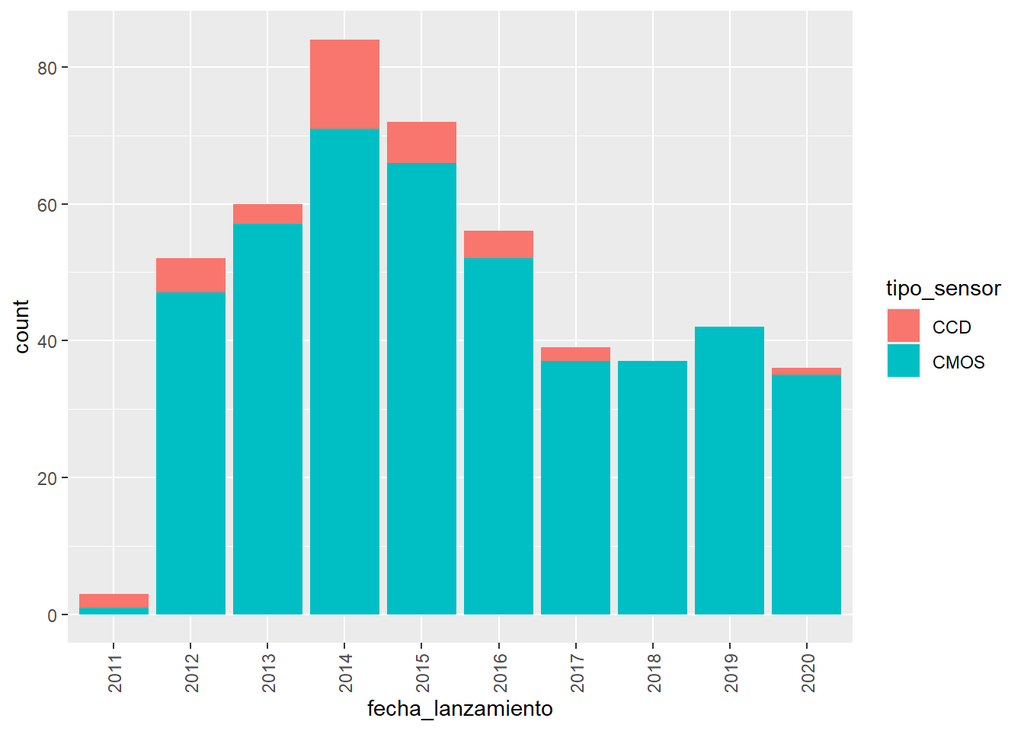

```r
ggplot(data, aes(x=fecha_lanzamiento, fill=tipo_sensor)) +
    geom_bar()+theme(axis.text.x = element_text(angle = 90, vjust = 0.5, hjust=1))
```

Veamos la evolución a continuación en función del tipo de cámara:

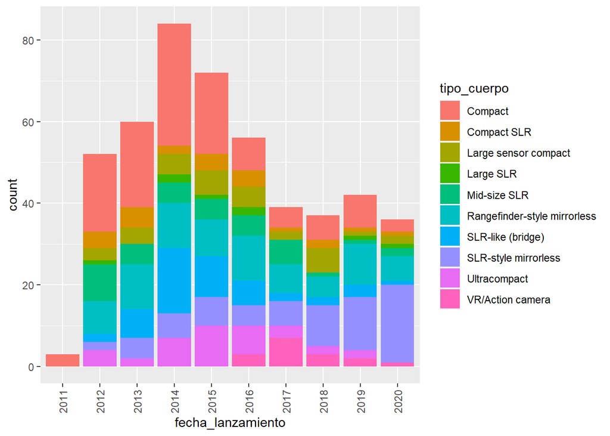

```r
ggplot(data, aes(x=fecha_lanzamiento, fill=tipo_cuerpo)) +
    geom_bar()+theme(axis.text.x = element_text(angle = 90, vjust = 0.5, hjust=1))
```